# Network tuning

Almut Luetge, Julian Baer

23 March 2020

## Network tuning

This demo and exercise goes through the most common parameters to optimize a neural network framework in keras and is following closely one of keras own examples at https://keras.rstudio.com/articles/tutorial_overfit_underfit.html.

#### Main objectives are:

- Setting up a “basic” neural network
- Monitoring it’s performance using model validation
- Fine-tune the network using network regularization

Libraries

```r
suppressPackageStartupMessages({
    library(keras)
    library(ggplot2)
    library(tibble)
    library(dplyr)
    library(tidyr)
})
```

### Dataset

We use the **Internet Movie DataBase (IMDB)** dataset here. It consists of 50000 highly polarized movie reviews, that should be classified into positive and negative from a model. So here we face a single label binary classification problem. This will guide major decisions on how to build our model. They are already split into *25,000 reviews* for *training* and *25,000 reviews* for *testing*, each set consisting of 50% negative and 50% positive reviews. So the training dataset should be representative for the test dataset.

We restrict ourselves to the 10000 most prevalent words.

```r
set.seed(2503)

#extract first 10'000 words
num_words <- 10000
imdb <- dataset_imdb(num_words = num_words)

# Define your training data: input tensors and target tensors
c(c(train_data, train_labels), c(test_data, test_labels)) %<-% imdb

#free some ram
rm(imdb)
gc()
```

```
##           used (Mb) gc trigger (Mb) max used (Mb)
## Ncells  804224 43.0    1532633 81.9  1243861 66.5
## Vcells 7290464 55.7   10841802 82.8  7676714 58.6
```

## Set up a “standard” keras workflow/basic network

### 1. Data preparation and setup

#### Data preparation:

- vectorization
- normalization
- handling missing values
- feature extraction/engineering

The reviews (sequences of words) have already been preprocessed into sequences of integers, where each integer stands for a specific word in a dictionary. The corresponding label are encoded into *0* and *1*, where 0 means a *negative* and 1 *positive* review.

```r
# Vectorize data to bring them into tensors of floating-point data
multi_hot_sequences <- function(sequences, dimension) {
  multi_hot <- matrix(0, nrow = length(sequences), ncol = dimension)
  for (i in 1:length(sequences)) {
    multi_hot[i, sequences[[i]]] <- 1
  }
  multi_hot
}

#apply custom multi hot function
train_data <- multi_hot_sequences(train_data, num_words)
test_data <- multi_hot_sequences(test_data, num_words)
test_labels <- as.numeric(test_labels)
train_labels <- as.numeric(train_labels)
```

We don’t need to *normalize* our data here as they represent sequences here, but for other datasets this can be key. There are no *missing values* in this dataset, but we already did some kind of *feature extraction/engineering* by choosing the first 10000 words. Less frequent words contain less information to learn from.

#### Defining an evaluation protocol

To fine tune our model we need **training data** to learn the model, **test data** to finally determine the models performance and **validation data**. These are used to evaluate the models performance using fine tuning. We can’t use the test data for this, as information from the “fine-tuning” leak into the model training. We can also choose between different validation strategies. If data size is a major limitation *k-fold validation* or *iterative k-fold-validation* can increase the power. Here we pick a *simple hold-out validation*.

```r
#get index of 10'000 randomly selected reviews from the train data
val_indices <- sample(1:nrow(train_data), 10000)

#extract these reviews and remove from train data
val_data <- train_data[val_indices,]
partial_train_data <- train_data[-val_indices,]
val_labels <- train_labels[val_indices]
partial_train_labels <- train_labels[-val_indices]
```

### 2. Model setup

Define a model that does better than baseline. Our parameter choices are mainly driven by the classification problem. We have a **binary classification** problem with a **single value**, so we pick **one unit** and **sigmoid activation** for the last layer. **Relu** activation for the other layers constrains our tensors to positive values, but other choices are possible. Findning an optimal size and number is not trivial. If we pick to many units the model will overfit and if we pick to few units the model will underfit. We start with a more complex (larger) baseline model and will further evaluate this using model validation.

```r
#define model
baseline_model <-
  keras_model_sequential() %>%
  layer_dense(units = 16, activation = "relu", input_shape = 10000) %>%
  layer_dense(units = 16, activation = "relu") %>%
  layer_dense(units = 1, activation = "sigmoid")
```

### 3. Model compilation

Configure the learning process by choosing a loss function, an optimizer, and which metrics to monitor during training.

As we model a binary classification we pick **binary_crossentropy** as loss function and monitor accuracy during training.

```r
#compile model
baseline_model %>% compile(
  optimizer = "adam",
  loss = "binary_crossentropy",
  metrics = c("accuracy")
)

#get number of parameters
baseline_model %>% summary()
```

```
## Model: "sequential"
## ________________________________________________________________________________
## Layer (type)                        Output Shape                    Param #
## ================================================================================
## dense (Dense)                       (None, 16)                      160016
## ________________________________________________________________________________
## dense_1 (Dense)                     (None, 16)                      272
## ________________________________________________________________________________
## dense_2 (Dense)                     (None, 1)                       17
## ================================================================================
## Total params: 160,305
## Trainable params: 160,305
## Non-trainable params: 0
## ________________________________________________________________________________
```

### 4. Learning

Iterate on your training data by calling the fit() method of your model

We start with a baseline model and evaluate it’s performance on the validation dataset:

```r
#fit model
history <- baseline_model %>% fit(
  partial_train_data,
  partial_train_labels,
  epochs = 20,
  batch_size = 512,
  validation_data = list(val_data, val_labels),
  verbose=1
)

#clean up
rm(baseline_model)
gc()
```

```
##             used   (Mb) gc trigger   (Mb)  max used   (Mb)
## Ncells    782134   41.8    1532633   81.9   1532633   81.9
## Vcells 751467589 5733.3 1084615508 8275.0 752208273 5738.9
```

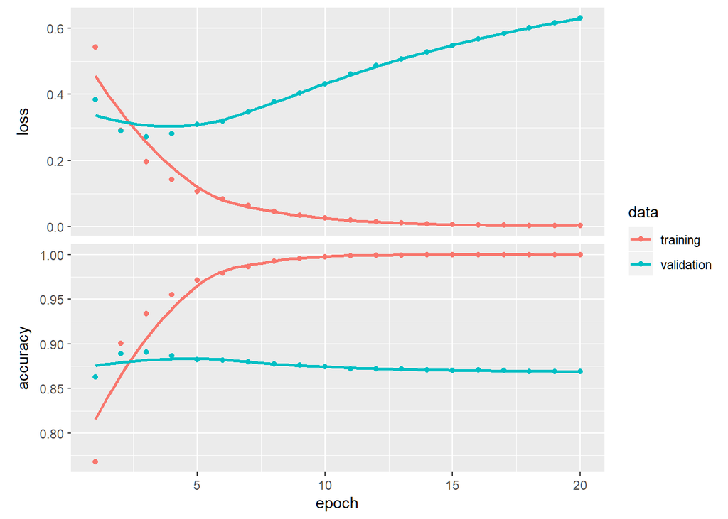

```r
#visualize model
plot(history)
```

We see a fair amount of overfitting happening quickly. The most straightforward way, at least conceptually, is getting more training data. In real world problems, this usually not so easy. Therefore, clever people invented mathematical approaches to reduce overfitting. Let’s explore some basic methods!

#### Model capacity: reduce the memorization ability

Model capacity is a not clearly defined term which is describing the complexity of a model and it’s capacity to learn and memorize patterns in the training data. The more capacity a model is given, the more likely it is to overfit to the training data as it is able to memorize every unique pattern. If the training data is scarce, reducing a model’s capacity might help reduce overfitting issues. Model capacity can be understood as the number of trainable parameters a model has. The number of trainable parameters is a combination of **input_shape**, **number of layers** and **number of units per layer**. So, we can drop some features of the training data (not covered here, this is part of what is called data pre-processing and feature engineering). Instead, we reduce the number of units (neurons) per layer. This should lead to a reduced capacity of the model and therefore prevent overfitting.

Let’s create such a smaller model

```r
#define model
smaller_model <-
  keras_model_sequential() %>%
  layer_dense(units = 4, activation = "relu", input_shape = 10000) %>%
  layer_dense(units = 4, activation = "relu") %>%
  layer_dense(units = 1, activation = "sigmoid")

#compile model
smaller_model %>% compile(
  optimizer = "adam",
  loss = "binary_crossentropy",
  metrics = list("accuracy")
)

#get number of parameters
smaller_model %>% summary()
```

```
## Model: "sequential_1"
## ________________________________________________________________________________
## Layer (type)                        Output Shape                    Param #
## ================================================================================
## dense_3 (Dense)                     (None, 4)                       40004
## ________________________________________________________________________________
## dense_4 (Dense)                     (None, 4)                       20
## ________________________________________________________________________________
## dense_5 (Dense)                     (None, 1)                       5
## ================================================================================
## Total params: 40,029
## Trainable params: 40,029
## Non-trainable params: 0
## ________________________________________________________________________________
```

```r
#fit model
smaller_history <- smaller_model %>% fit(
  partial_train_data,
  partial_train_labels,
  epochs = 20,
  batch_size = 512,
  validation_data = list(val_data, val_labels),
  verbose = 1
)

#clean up
rm(smaller_model)
gc()
```

```
##             used   (Mb) gc trigger   (Mb)  max used   (Mb)
## Ncells    916489   49.0    1532633   81.9   1532633   81.9
## Vcells 751724548 5735.3 1084615508 8275.0 752666166 5742.4
```

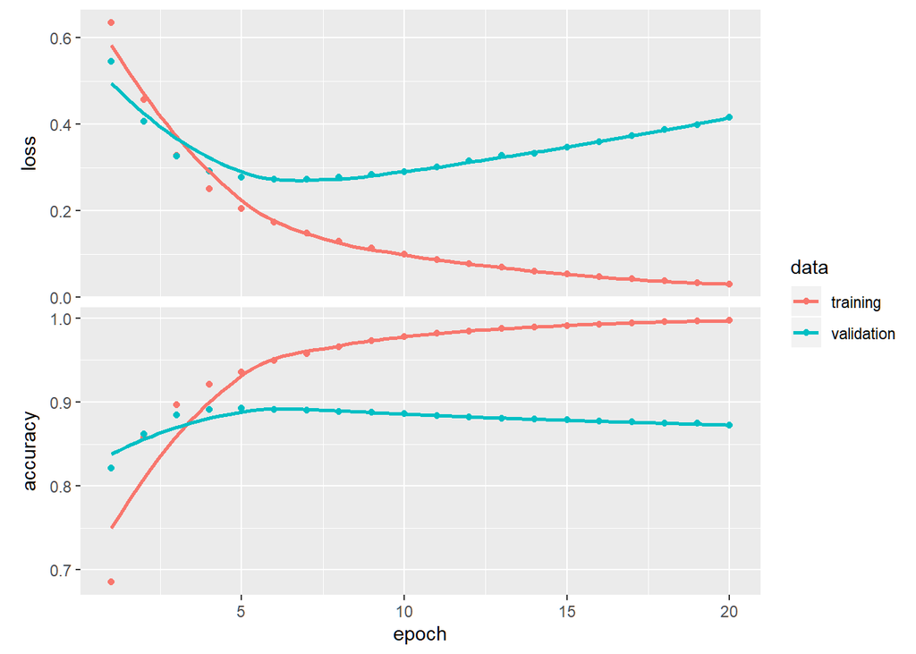

```r
#plot
plot(smaller_history)
```

And compare the smaller model to the baseline model to see how it affects loss in training and validation data.

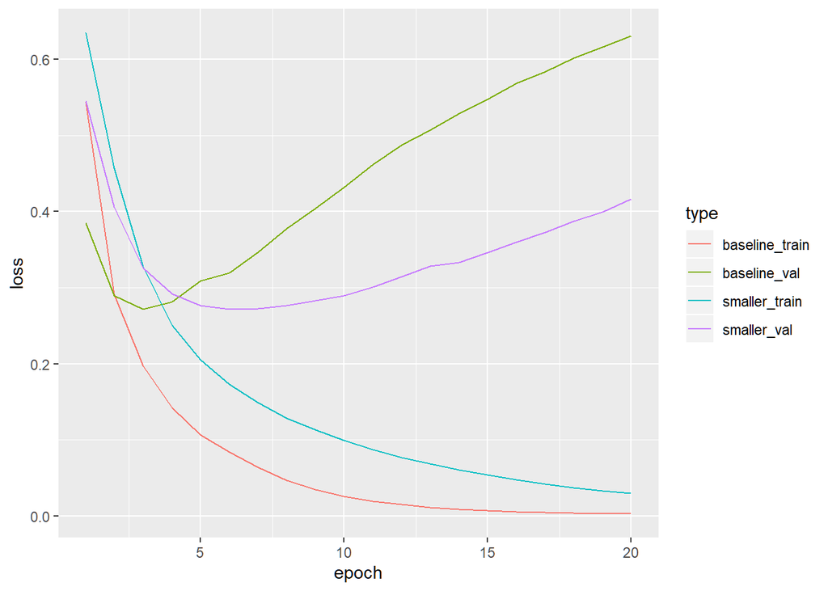

```r
#combine history of 2 models into a data.frame
compare_cx <- data.frame(
  baseline_train = history$metrics$loss,
  baseline_val = history$metrics$val_loss,
  smaller_train = smaller_history$metrics$loss,
  smaller_val = smaller_history$metrics$val_loss
) %>%
  rownames_to_column() %>%
  mutate(rowname = as.integer(rowname)) %>%
  gather(key = "type", value = "value", -rowname)

#plot both models
ggplot(compare_cx, aes(x = rowname, y = value, color = type)) +
  geom_line() +
  xlab("epoch") +
  ylab("loss")
```

```r
#clean up
rm(smaller_history)
rm(compare_cx)
gc()
```

```
##             used   (Mb) gc trigger   (Mb)  max used   (Mb)
## Ncells    972246   52.0    1532633   81.9   1532633   81.9
## Vcells 751838675 5736.1 1084615508 8275.0 752666166 5742.4
```

#### Dropouts

Ok, we saw that reducing model capacity helps to reduce overfitting issues. Another often used method are dropout layers. Dropout layers randomly “drop out” (i.e. set to zero) some of the features of the previous layer to introduce some noise. This was shown to reduce the chance that the model fit learns specific features of the training data. The user sets the drop-out rate which is the fraction of features which are dropped. Common values range from 0.2 to 0.5. Let’s add two high fraction (0.6) dropout layers in our baseline model. This might introduce underfitting! Also, note that R gives you a warning that 0.6 is too high and should be reduced…

```r
#define model
dropout_model <-
  keras_model_sequential() %>%
  layer_dense(units = 16, activation = "relu", input_shape = 10000) %>%
  layer_dropout(0.6) %>%
  layer_dense(units = 16, activation = "relu") %>%
  layer_dropout(0.6) %>%
  layer_dense(units = 1, activation = "sigmoid")

#compile
dropout_model %>% compile(
  optimizer = "adam",
  loss = "binary_crossentropy",
  metrics = list("accuracy")
)

#fit
dropout_history <- dropout_model %>% fit(
  train_data,
  train_labels,
  epochs = 20,
  batch_size = 512,
  validation_data = list(test_data, test_labels),
  verbose = 1
)

#clean up
rm(dropout_model)
gc()
```

```
##             used   (Mb) gc trigger   (Mb)  max used   (Mb)
## Ncells    930957   49.8    1532633   81.9   1532633   81.9
## Vcells 751757784 5735.5 1084615508 8275.0 752666166 5742.4
```

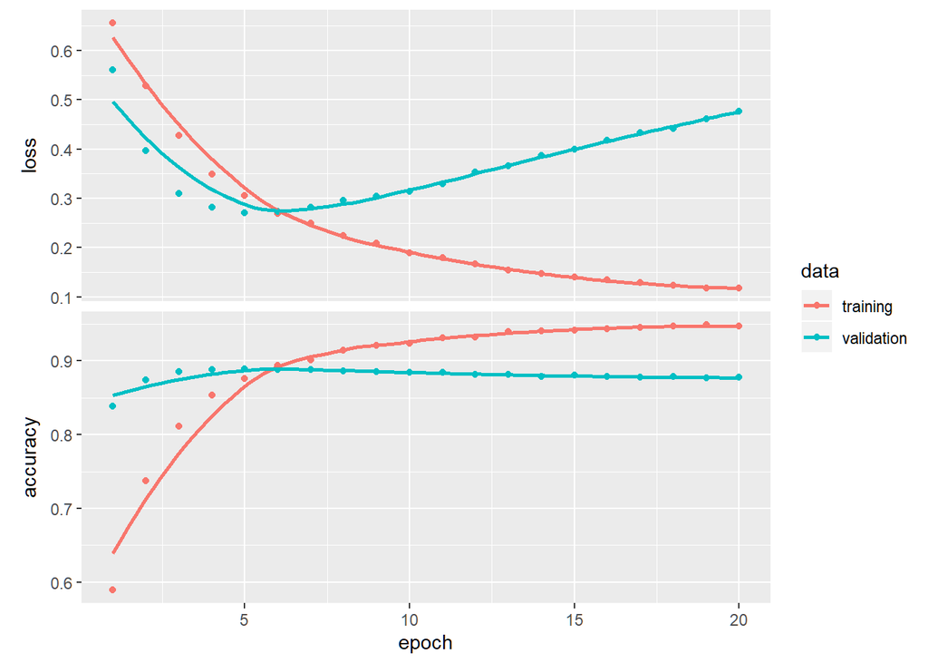

```r
#plot
plot(dropout_history)
```

Nice! Let’s look at the loss of the baseline and dropout model in one graph

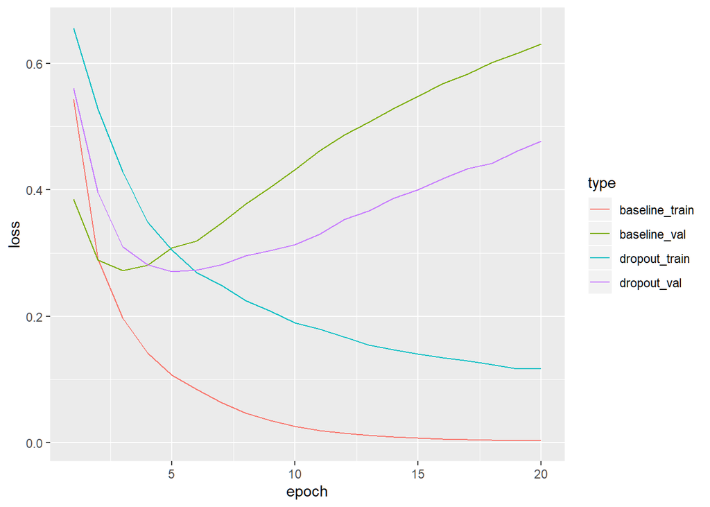

```r
#combine history of 2 models into a data.frame
compare_cx <- data.frame(
  baseline_train = history$metrics$loss,
  baseline_val = history$metrics$val_loss,
  dropout_train = dropout_history$metrics$loss,
  dropout_val = dropout_history$metrics$val_loss
) %>%
  rownames_to_column() %>%
  mutate(rowname = as.integer(rowname)) %>%
  gather(key = "type", value = "value", -rowname)

#plot
ggplot(compare_cx, aes(x = rowname, y = value, color = type)) +
  geom_line() +
  xlab("epoch") +
  ylab("loss")
```

```r
#clean up
rm(dropout_history)
rm(dropout_model)
rm(compare_cx)
gc()
```

```
##             used   (Mb) gc trigger   (Mb)  max used   (Mb)
## Ncells    972351   52.0    1532633   81.9   1532633   81.9
## Vcells 751839212 5736.1 1084615508 8275.0 752666166 5742.4
```

And again, dropout works well to reduce overfiting but we still have discrepancy between the train and eval data.

#### Early stopping

The longer a model can run, the more time it has to learn unique patterns in the training set. Especially if a model fit is done for a couple hundred epochs, the chance to plateau regarding loss is high. Even worse, the loss of the training data may stagnate but the loss of the validation set is increasing! Therefore, one can implement a early stopping callback function into the model fit. Callback functions are injectable functions that are evaluated during the model fit.

**!WARNING!** The early stopping is extremely RAM-intenisve because it is storing every model for as many epochs as you speciy in the patience parameter. If you want to run it, monitor your RAM and stop the fit before you kill your computer :)

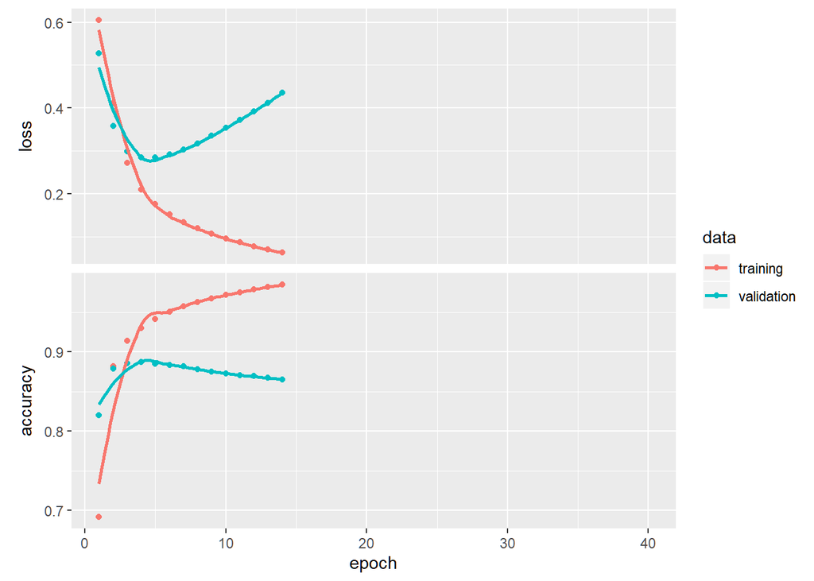

```r
# The patience parameter is the amount of epochs to check for improvement.
early_stop <- callback_early_stopping(monitor = "val_loss", patience = 10)

#define model
stop_model <-
  keras_model_sequential() %>%
  layer_dense(units = 4, activation = "relu", input_shape = 10000) %>%
  layer_dense(units = 4, activation = "relu") %>%
  layer_dense(units = 1, activation = "sigmoid")

#compile model
stop_model %>% compile(
  optimizer = "adam",
  loss = "binary_crossentropy",
  metrics = c("accuracy")
)

#fit model
history_stop <- stop_model %>% fit(
  train_data,
  train_labels,
  epochs = 40,
  batch_size=512,
  validation_data = list(test_data, test_labels),
  verbose = 1,
  callbacks = list(early_stop)
)

#plot
plot(history_stop)
```

```r
#clean up
rm(stop_model)
rm(history_stop)
gc()
```

```
##             used   (Mb) gc trigger   (Mb)  max used   (Mb)
## Ncells    968529   51.8    1532633   81.9   1532633   81.9
## Vcells 751836739 5736.1 1084615508 8275.0 752666166 5742.4
```

#### Network regularization

A more sophisticated method is weight regularization: adding to the loss function of the network a cost associated with having large weights.

Here we show the effect of **L2-regularization** on the model’s overfitting. L2 regularization adds a cost proportional to the squared value of weight coefficients. We can also determine the cost added per weight coefficient - in this case it’s 1 percent of the coefficients value.

```r
#define model
l2_model <- keras_model_sequential() %>%
  layer_dense(units = 16, kernel_regularizer = regularizer_l2(0.01),
              activation = "relu", input_shape = c(10000)) %>%
  layer_dense(units = 16, kernel_regularizer = regularizer_l2(0.01),
              activation = "relu") %>%
  layer_dense(units = 1, activation = "sigmoid")
```

We can check the effect of L2 generelization the same way as before using the same validation data set:

```r
#compile
l2_model %>% compile(
  optimizer = "adam",
  loss = "binary_crossentropy",
  metrics = c("accuracy")
)

#fit
history_l2 <- l2_model %>% fit(
  partial_train_data,
  partial_train_labels,
  epochs = 20,
  batch_size = 512,
  validation_data = list(val_data, val_labels)
)

#clean up
rm(l2_model)
gc()
```

```
##             used   (Mb) gc trigger   (Mb)  max used   (Mb)
## Ncells    931869   49.8    1532633   81.9   1532633   81.9
## Vcells 751759108 5735.5 1084615508 8275.0 752666166 5742.4
```

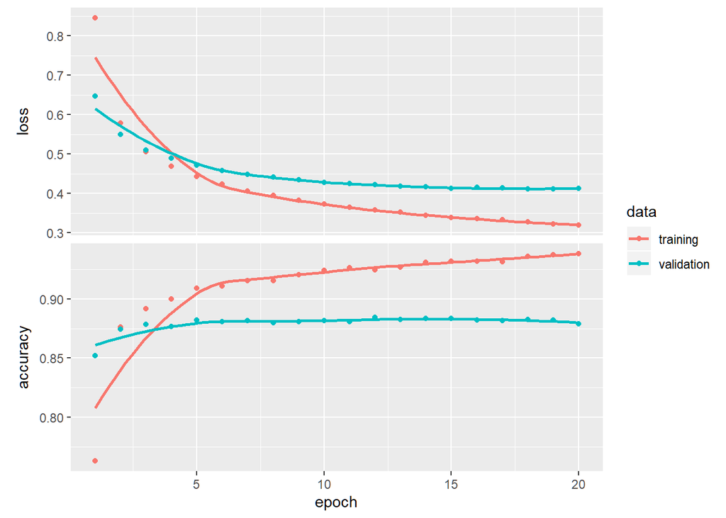

```r
#plot
plot(history_l2)
```

```r
#clean up
rm(history_l2)
gc()
```

```
##             used   (Mb) gc trigger   (Mb)  max used   (Mb)
## Ncells    968497   51.8    1532633   81.9   1532633   81.9
## Vcells 751836400 5736.1 1084615508 8275.0 752666166 5742.4
```

Try to remember how many different models you tried!

### 5.Test the final model

```r
#free some ram
remove(partial_train_data)
remove(partial_train_labels)
gc()
```

```
##             used   (Mb) gc trigger   (Mb)  max used   (Mb)
## Ncells    931904   49.8    1532633   81.9   1532633   81.9
## Vcells 601744527 4591.0 1084615508 8275.0 752666166 5742.4
```

```r
#define model
final_model <- keras_model_sequential() %>%
    layer_dense(units = 8, kernel_regularizer = regularizer_l1_l2(0.01),
                activation = "relu", input_shape = c(10000)) %>%
    layer_dropout(0.4) %>%
    layer_dense(units = 8, kernel_regularizer = regularizer_l1_l2(0.01),
                activation = "relu") %>%
    layer_dropout(0.4) %>%
    layer_dense(units = 1, activation = "sigmoid")

#compile
final_model %>% compile(
  optimizer = "adam",
  loss = "binary_crossentropy",
  metrics = c("accuracy")
)

#fit on complete train_data
final_model %>% fit(
  train_data,
  train_labels,
  epochs = 20,
  batch_size = 512
)

#and evaluate on test data
results <- final_model %>% evaluate(test_data, test_labels)
results
```

```
## $loss
## [1] 0.7546591
##
## $accuracy
## [1] 0.77988
```

Is this what you expected? What could have happened, if the test accuracy differs from the validation accuracy?